# hw_02

## Overview

The goal is to explore a dataset. In particular, to begin to establish a workflow for data frames or “tibbles”. This homework will use dplyr and ggplot2 to do some description and visualization.

## library the data set

```r
library(gapminder)
library(tidyverse)
```

## Explore the gapminder object:

1. Is it a data.frame, a matrix, a vector, a list?

```r
class(gapminder)
```

```
## [1] "tbl_df"     "tbl"        "data.frame"
```

Answer: The object of gapminder is a “data.frame”.

2. What is its class?

```r
class(gapminder)
```

```
## [1] "tbl_df"     "tbl"        "data.frame"
```

Answer: The class of gapminder is a “tbl_df”.

3,4. How many variables/columns and rows/observations?

```r
ncol(gapminder)
```

```
## [1] 6
```

```r
nrow(gapminder)
```

```
## [1] 1704
```

Answer: There are 6 colums and 1704 rows.

5. Can you get these facts about “extent” or “size” in more than one way? Can you imagine different functions being useful in different contexts?

```r
str(gapminder)
```

```
## Classes 'tbl_df', 'tbl' and 'data.frame':    1704 obs. of  6 variables:
##  $ country  : Factor w/ 142 levels "Afghanistan",..: 1 1 1 1 1 1 1 1 1 1 ...
##  $ continent: Factor w/ 5 levels "Africa","Americas",..: 3 3 3 3 3 3 3 3 3 3 ...
##  $ year     : int  1952 1957 1962 1967 1972 1977 1982 1987 1992 1997 ...
##  $ lifeExp  : num  28.8 30.3 32 34 36.1 ...
##  $ pop      : int  8425333 9240934 10267083 11537966 13079460 14880372 12881816 13867957 16317921 22227415 ...
##  $ gdpPercap: num  779 821 853 836 740 ...
```

```r
glimpse(gapminder)
```

```
## Observations: 1,704
## Variables: 6
## $ country   <fct> Afghanistan, Afghanistan, Afghanistan, Afghanistan, ...
## $ continent <fct> Asia, Asia, Asia, Asia, Asia, Asia, Asia, Asia, Asia...
## $ year      <int> 1952, 1957, 1962, 1967, 1972, 1977, 1982, 1987, 1992...
## $ lifeExp   <dbl> 28.801, 30.332, 31.997, 34.020, 36.088, 38.438, 39.8...
## $ pop       <int> 8425333, 9240934, 10267083, 11537966, 13079460, 1488...
## $ gdpPercap <dbl> 779.4453, 820.8530, 853.1007, 836.1971, 739.9811, 78...
```

```r
summary(gapminder)
```

```
##         country        continent        year         lifeExp
##  Afghanistan:  12   Africa  :624   Min.   :1952   Min.   :23.60
##  Albania    :  12   Americas:300   1st Qu.:1966   1st Qu.:48.20
##  Algeria    :  12   Asia    :396   Median :1980   Median :60.71
##  Angola     :  12   Europe  :360   Mean   :1980   Mean   :59.47
##  Argentina  :  12   Oceania : 24   3rd Qu.:1993   3rd Qu.:70.85
##  Australia  :  12                  Max.   :2007   Max.   :82.60
##  (Other)    :1632
##       pop              gdpPercap
##  Min.   :6.001e+04   Min.   :   241.2
##  1st Qu.:2.794e+06   1st Qu.:  1202.1
##  Median :7.024e+06   Median :  3531.8
##  Mean   :2.960e+07   Mean   :  7215.3
##  3rd Qu.:1.959e+07   3rd Qu.:  9325.5
##  Max.   :1.319e+09   Max.   :113523.1
##
```

```r
ls(gapminder)
```

```
## [1] "continent" "country"   "gdpPercap" "lifeExp"   "pop"       "year"
```

Answer: “str”" function can get these facts, such as classes, objects, variables. Similarly, “glimpse”" can return the details of dataset while this method tries to show you as much data as possible. Another userful function is “summary”“, which returns the values such as median, mean, max of the each variable. Function”ls“” is also useful in returning the variables.

6. What data type is each variable? Answer: according to results of questions 5, the data of each variable is shown as below: $ country $ continent $ year $ lifeExp $ pop $ gdpPercap

## Explore individual variables

1. What are possible values (or range, whichever is appropriate) of each variable?

```r
## let's make a data frame containing the columns year, pop, continent from the gapminder dat.
select(gapminder,year,pop, continent) %>%
  arrange(year, pop) %>% # Then order by year, then by pop
  filter(pop > 1000000000 & year >= 2002) %>% # Then fliter the data with population more than 1 billion and year more than 2002
  knitr::kable()
```

| year | pop | continent |
| --- | --- | --- |
| 2002 | 1034172547 | Asia |
| 2002 | 1280400000 | Asia |
| 2007 | 1110396331 | Asia |
| 2007 | 1318683096 | Asia |

2. What values are typical? What’s the spread? What’s the distribution? Etc., tailored to the variable at hand.

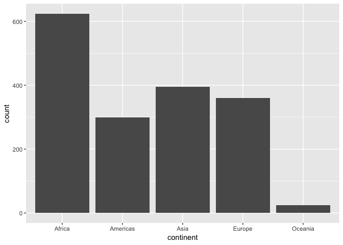

```r
##scale can be viewed use bar chart
  ggplot(gapminder,aes(x = continent)) +
  geom_bar()
```

```r
gapminder %>%
##distribution can be viewd use summary
  select(year, pop,continent, lifeExp) %>%
  summary() %>%
  knitr::kable()
```

|  | year | pop | continent | lifeExp |
| --- | --- | --- | --- | --- |
|  | Min. :1952 | Min. :6.001e+04 | Africa :624 | Min. :23.60 |
|  | 1st Qu.:1966 | 1st Qu.:2.794e+06 | Americas:300 | 1st Qu.:48.20 |
|  | Median :1980 | Median :7.024e+06 | Asia :396 | Median :60.71 |
|  | Mean :1980 | Mean :2.960e+07 | Europe :360 | Mean :59.47 |
|  | 3rd Qu.:1993 | 3rd Qu.:1.959e+07 | Oceania : 24 | 3rd Qu.:70.85 |
|  | Max. :2007 | Max. :1.319e+09 | NA | Max. :82.60 |

```r
##The counts for variables for each year are the same (142). This happens in country (12) as well
table(gapminder$year) %>%
  knitr::kable()
```

| Var1 | Freq |
| --- | --- |
| 1952 | 142 |
| 1957 | 142 |
| 1962 | 142 |
| 1967 | 142 |
| 1972 | 142 |
| 1977 | 142 |
| 1982 | 142 |
| 1987 | 142 |
| 1992 | 142 |
| 1997 | 142 |
| 2002 | 142 |
| 2007 | 142 |

```r
table(gapminder$country) %>%
  knitr::kable()
```

| Var1 | Freq |
| --- | --- |
| Afghanistan | 12 |
| Albania | 12 |
| Algeria | 12 |
| Angola | 12 |
| Argentina | 12 |
| Australia | 12 |
| Austria | 12 |
| Bahrain | 12 |
| Bangladesh | 12 |
| Belgium | 12 |
| Benin | 12 |
| Bolivia | 12 |
| Bosnia and Herzegovina | 12 |
| Botswana | 12 |
| Brazil | 12 |
| Bulgaria | 12 |
| Burkina Faso | 12 |
| Burundi | 12 |
| Cambodia | 12 |
| Cameroon | 12 |
| Canada | 12 |
| Central African Republic | 12 |
| Chad | 12 |
| Chile | 12 |
| China | 12 |
| Colombia | 12 |
| Comoros | 12 |
| Congo, Dem. Rep. | 12 |
| Congo, Rep. | 12 |
| Costa Rica | 12 |

[output cut: 112 more lines]

## Explore various plot types

Make a few plots, probably of the same variable you chose to characterize numerically. Let’s see the relationship between life expectancy and continent

```r
PLOT <- ggplot(gapminder, aes(x=continent, y=lifeExp))
```

1. scatterplot

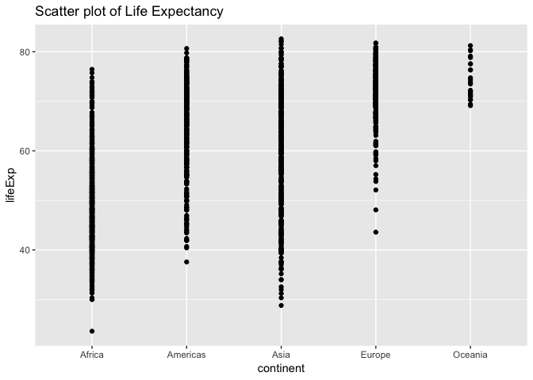

```r
  PLOT + geom_point() +
  ggtitle("Scatter plot of Life Expectancy")
```

2. box plot

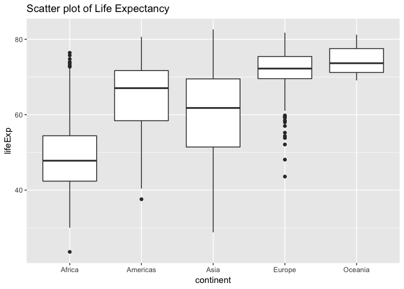

```r
 PLOT + geom_boxplot() +
    ggtitle("Scatter plot of Life Expectancy")
```

3. violin plot

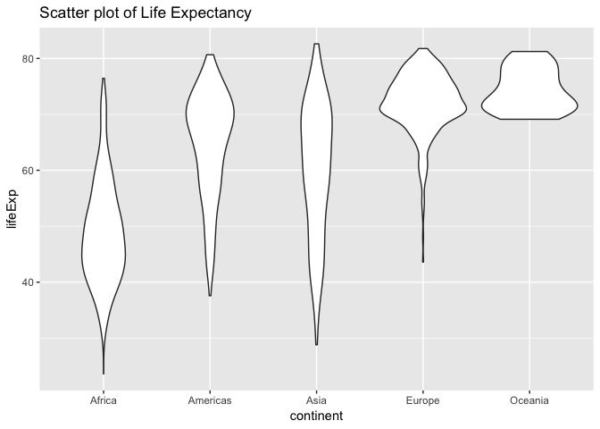

```r
 PLOT + geom_violin() +
    ggtitle("Scatter plot of Life Expectancy")
```

4. overlap geom_violin and jitter plot

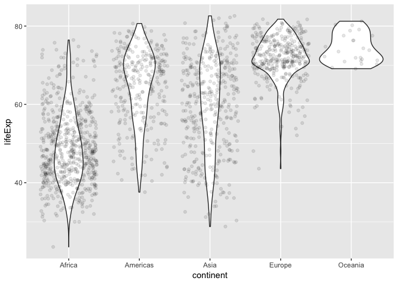

```r
 PLOT + geom_violin() +
  geom_jitter(alpha = 0.1)
```

5. let’s see the life expantancy in Americas with popolation more than 50 milion

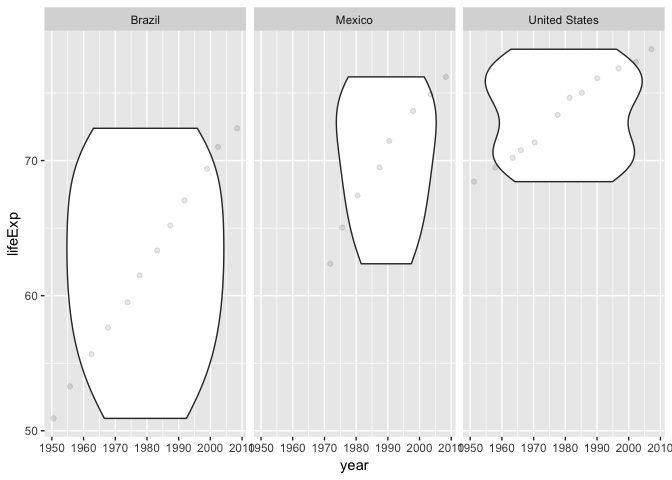

```r
 gapminder %>%
  filter(continent == "Americas") %>%
  filter(pop >= 50000000) %>%
  ggplot(aes(year, lifeExp, group = 1)) +
  facet_grid(~country) +
  geom_violin() +
  geom_jitter(alpha = 0.1)
```

6. let’s compare lifeExp in Americas and in Asia with popolation more than 50 milion

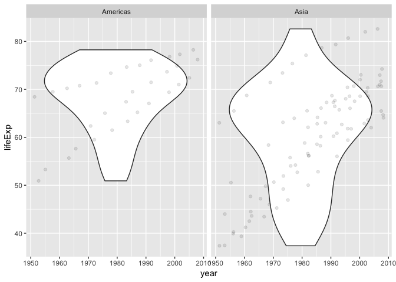

```r
 gapminder %>%
  filter(continent == "Americas" | continent == "Asia") %>%
  filter(pop >= 50000000) %>%
  ggplot(aes(year, lifeExp, group = 1)) +
  facet_grid(~continent) +
  geom_violin() +
  geom_jitter(alpha = 0.1)
```

## But I want to do more!

```r
filter(gapminder, country == c("Rwanda", "Afghanistan")) %>%
knitr::kable()
```

[output not shown]

One possible solution is given by:

```r
  filter(gapminder, country == "Rwanda" | country == "Afghanistan") %>%
  knitr::kable()
```

| country | continent | year | lifeExp | pop | gdpPercap |
| --- | --- | --- | --- | --- | --- |
| Afghanistan | Asia | 1952 | 28.801 | 8425333 | 779.4453 |
| Afghanistan | Asia | 1957 | 30.332 | 9240934 | 820.8530 |
| Afghanistan | Asia | 1962 | 31.997 | 10267083 | 853.1007 |
| Afghanistan | Asia | 1967 | 34.020 | 11537966 | 836.1971 |
| Afghanistan | Asia | 1972 | 36.088 | 13079460 | 739.9811 |
| Afghanistan | Asia | 1977 | 38.438 | 14880372 | 786.1134 |
| Afghanistan | Asia | 1982 | 39.854 | 12881816 | 978.0114 |
| Afghanistan | Asia | 1987 | 40.822 | 13867957 | 852.3959 |
| Afghanistan | Asia | 1992 | 41.674 | 16317921 | 649.3414 |
| Afghanistan | Asia | 1997 | 41.763 | 22227415 | 635.3414 |
| Afghanistan | Asia | 2002 | 42.129 | 25268405 | 726.7341 |
| Afghanistan | Asia | 2007 | 43.828 | 31889923 | 974.5803 |
| Rwanda | Africa | 1952 | 40.000 | 2534927 | 493.3239 |
| Rwanda | Africa | 1957 | 41.500 | 2822082 | 540.2894 |
| Rwanda | Africa | 1962 | 43.000 | 3051242 | 597.4731 |
| Rwanda | Africa | 1967 | 44.100 | 3451079 | 510.9637 |
| Rwanda | Africa | 1972 | 44.600 | 3992121 | 590.5807 |
| Rwanda | Africa | 1977 | 45.000 | 4657072 | 670.0806 |
| Rwanda | Africa | 1982 | 46.218 | 5507565 | 881.5706 |
| Rwanda | Africa | 1987 | 44.020 | 6349365 | 847.9912 |
| Rwanda | Africa | 1992 | 23.599 | 7290203 | 737.0686 |
| Rwanda | Africa | 1997 | 36.087 | 7212583 | 589.9445 |
| Rwanda | Africa | 2002 | 43.413 | 7852401 | 785.6538 |
| Rwanda | Africa | 2007 | 46.242 | 8860588 | 863.0885 |